# Guided Project: Scales and Facets

CIS-3901 · Module 13

Author

Aubree Robinson

Published

November 17, 2026

**ImportantEdit the code in the script. The report and the slides only read it.**

The code lives in `scripts/gp13_scales_facets.R`. Your words (findings, headlines, limits) live in the report and the slides. Keep the code chunks here empty: on render, each one runs the script’s code, so code typed into them is ignored. Fix the code in the script.

## My data

Sports Dataset: The NFL Combine dataset contains performance measurements from football players who participated in the NFL Combine. One row represents one player and includes variables such as position, 40-yard dash time, vertical jump, broad jump, shuttle time, bench repetitions, and draft round. The dataset contains approximately 6,000 rows. The data come from NFL Combine records provided for course analysis (see References).

Hospital Readmissions Dataset. (n.d.). Hospital patient readmissions data. Course dataset provided by professor for educational use.

NFL Combine Dataset. (n.d.). NFL Combine player performance data. Course dataset provided professor for educational use.

```r
put_in_place("fairness.csv")
put_in_place("sports.csv")

fairness <- read_csv("data/fairness.csv", show_col_types = FALSE)
sports <- read_csv("data/sports.csv", show_col_types = FALSE)

if (looks_damaged(fairness) || looks_damaged(sports)) {
  stop("One of your data files looks damaged (each row in one column): it ",
       "may have been re-saved by a spreadsheet app. Ask your instructor ",
       "for a fresh copy.", call. = FALSE)
}

# Your columns ("values" = how many different values: 2 to 4 suits
# task 5). Never put a column of people's names in a plot.
show_columns(fairness)
```

```
# A tibble: 22 × 4
   column              type      values missing
   <chr>               <chr>      <int>   <int>
 1 encounter_id        numeric     5000       0
 2 race                character      6       0
 3 gender              character      3       0
 4 age                 character      3       0
 5 time_in_hospital    numeric       14       0
 6 num_lab_procedures  numeric       99       0
 7 num_procedures      numeric        7       0
 8 num_medications     numeric       63       0
 9 number_diagnoses    numeric       11       0
10 primary_diagnosis   character      5       0
11 max_glu_serum       character      4       0
12 A1Cresult           character      4       0
13 insulin             character      4       0
14 change              character      2       0
15 diabetesMed         character      2       0
16 medicare            logical        2       0
17 medicaid            logical        2       0
18 had_emergency       logical        2       0
19 had_inpatient_days  logical        2       0
20 had_outpatient_days logical        2       0
21 readmitted          character      3       0
22 readmit_30_days     numeric        2       0
```

```r
show_columns(sports)
```

```
# A tibble: 8 × 4
  column     type      values missing
  <chr>      <chr>      <int>   <int>
1 position   character     19       0
2 Round      numeric        8    2105
3 forty      numeric      158     377
4 vertical   numeric       59    1163
5 bench_reps numeric       46    1820
6 broad_jump numeric       64    1237
7 three_cone numeric      214    2143
8 shuttle    numeric      149    2035
```

```r
# PART A · FAIRNESS ==========================================================

# A0 · See it update ---------------------------------------------------------
# A ready count plot of one of your Fairness columns. Nothing to code.
# YOUR TURN (kickoff): change one word in the title, then render the report
# and the slides, and find your word on both pages.
```

## Part A · Fairness

### A0 · See it update

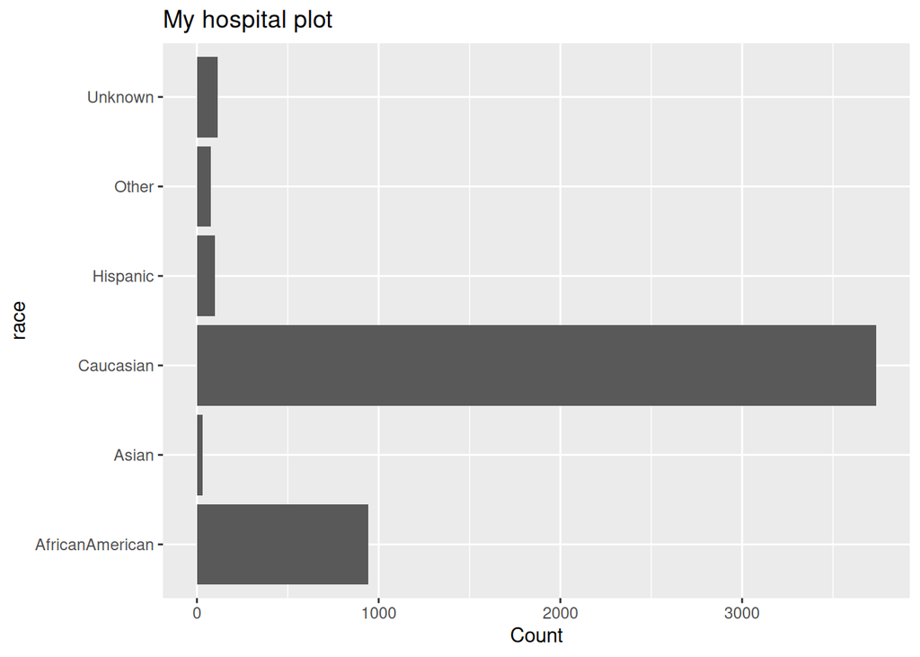

Figure 1: My first plot: a count of one of my Fairness columns.

```r
a0_column <- pick_a_column(fairness)

a0 <- ggplot(fairness, aes(y = .data[[a0_column]])) +
  geom_bar() +
  labs(
    title = "My hospital plot",
    x = "Count",
    y = a0_column
  )

show_plot(a0)
```

WRITE (1 sentence):The title change appeared in both the report and the slides after rendering, confirming that the update was applied successfully.

### A1 · Label it

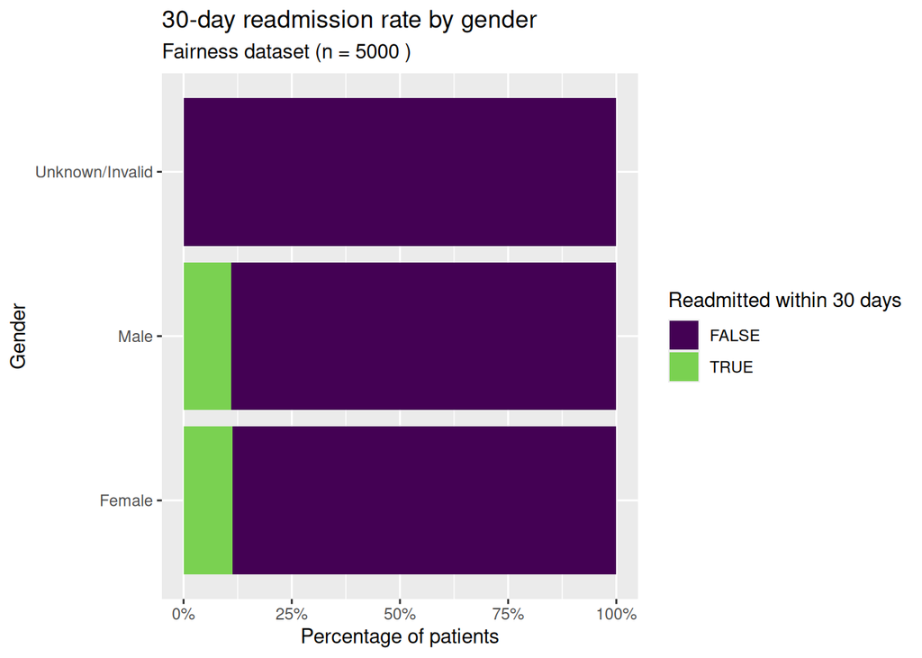

Figure 2: Share of each group with the outcome, labeled for a reader.

```r
a_data <- fairness %>%
  mutate(
    group = gender,
    has_outcome = readmit_30_days == 1
  )

a1_base <-  ggplot (a_data,
    aes(y = group, fill = has_outcome))+
  geom_bar(position = "fill")

a1 <- a1_base +
  labs(
    title = "30-day readmission rate by gender",
    subtitle = paste("Fairness dataset (n =", nrow(a_data), ")"),
    x = "Percentage of patients",
    y = "Gender",
    fill = "Readmitted within 30 days"
  ) +
  scale_x_continuous(labels = scales::percent)

show_plot(a1)
```

WRITE (2 sentences): Which label did you change most, and why? Could a reader understand this plot without you there?

I changed the title the most because it needed to clearly explain that the plot shows 30-day readmission rates by gender and help readers understand the purpose of the chart immediately.

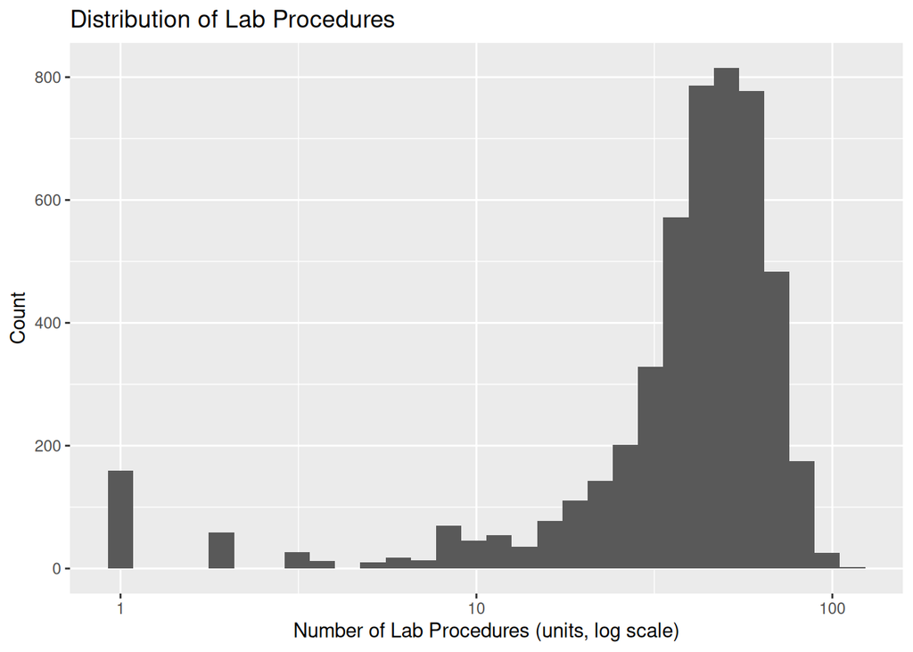

```r
a2 <- NULL
# YOUR TURN: remove the # signs below, then replace each ___.
  a2 <- fairness %>%
  filter(num_lab_procedures > 0) %>%
  ggplot(aes(x = num_lab_procedures)) +
  geom_histogram(bins = 30) +
  scale_x_log10(labels = scales::comma) +
  labs(title = "Distribution of Lab Procedures", x = "Number of Lab Procedures (units, log scale)", y = "Count")

# YOUR TURN: one sentence. Why this scale for this column?
a2_reason <- "I used log scale because num_lab_procedures is skewed, with many small vaules and fewer larger values."

show_plot(a2)
```

### A3 · Facet it: fixed or free

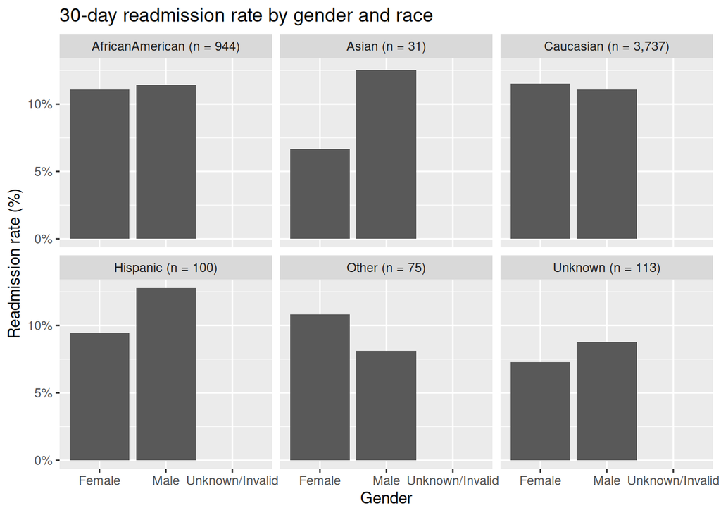

(a) Fixed

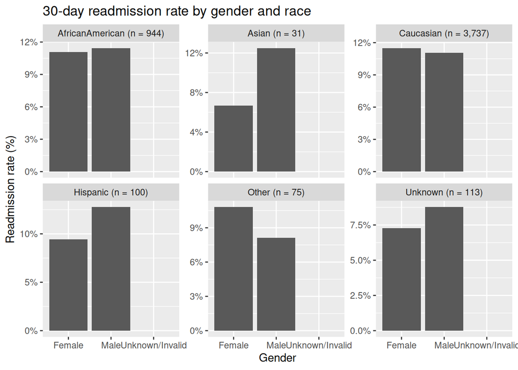

(b) Free

Figure 3: The same rates in panels: fixed and free y-axes.

```r
# YOUR TURN 1: replace "replace me" with your second column (no quotes).
a3_rates <- a_data %>%
  mutate(panel = race) %>%
  drop_na(has_outcome) %>%
  add_count(panel, name = "panel_n") %>%
  mutate(panel = paste0(panel, " (n = ", scales::comma(panel_n), ")")) %>%
  group_by(panel, group) %>%
  summarize(n = n(), rate = mean(has_outcome), .groups = "drop")

a3_fixed <- ggplot(a3_rates, aes(x = group, y = rate)) +
  geom_col() +
  facet_wrap(vars(panel)) +
  scale_y_continuous(labels = scales::percent) +
  labs(
    title = "30-day readmission rate by gender and race",
    x = "Gender",
    y = "Readmission rate (%)"
  )

a3_free <- a3_fixed +
  facet_wrap(vars(panel), scales = "free_y")

# YOUR TURN 2: remove the # signs below, then replace each ___.
# a3_fixed <- ggplot(a3_rates, aes(x = group, y = rate)) +
#   geom_col() +
#   facet_wrap(vars(panel)) +
#   scale_y_continuous(labels = scales::percent) +
#   labs(title = "___", x = "___", y = "___ (%)")
# a3_free <- a3_fixed +
#   facet_wrap(vars(panel), scales = "free_y")

# YOUR TURN 3: which one would you publish, "fixed" or "free_y"? Why?
a3_choice <- "fixed"
a3_reason <- "A fixed y-axis makes it easier and more accurate to compare readmission rates across panels."
show_plot(a3_fixed)
show_plot(a3_free)
```

Table 1: Each group’s n and rate, by panel.

| panel | group | n | rate |
| --- | --- | --- | --- |
| AfricanAmerican (n = 944) | Female | 577 | 0.111 |
| AfricanAmerican (n = 944) | Male | 367 | 0.114 |
| Asian (n = 31) | Female | 15 | 0.067 |
| Asian (n = 31) | Male | 16 | 0.125 |
| Caucasian (n = 3,737) | Female | 1948 | 0.115 |
| Caucasian (n = 3,737) | Male | 1789 | 0.111 |
| Hispanic (n = 100) | Female | 53 | 0.094 |
| Hispanic (n = 100) | Male | 47 | 0.128 |
| Other (n = 75) | Female | 37 | 0.108 |
| Other (n = 75) | Male | 37 | 0.081 |
| Other (n = 75) | Unknown/Invalid | 1 | 0.000 |
| Unknown (n = 113) | Female | 55 | 0.073 |
| Unknown (n = 113) | Male | 57 | 0.088 |
| Unknown (n = 113) | Unknown/Invalid | 1 | 0.000 |

WRITE (3–4 sentences): Fixed or free? What does the reader gain, and what do they lose? Which panels or groups are small, and what is their n? Describe differences, not causes.

I would publish the fixed version because all panels use the same y-axis scale, making it easier to compare readmission rates across racial groups. Readers gain more accurate comparisons between panels, although small differences may be harder to see than in the free-scale version. The sample sizes for each racial group are shown in the panel labels as n values, and groups with smaller sample sizes should be interpreted more cautiously. The figure shows differences in readmission rates across gender and race groups, but it does not explain the causes of those differences.

### A4 · Compared to what?

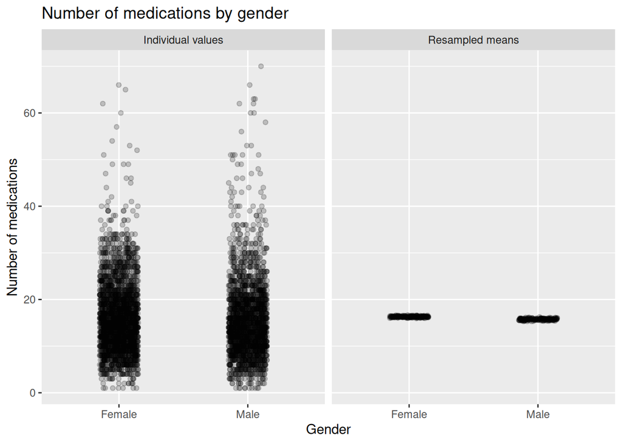

Figure 4: Two groups: individual values and resampled means, same axes.

```r
a4_clouds <- a_data %>%
  filter(group %in% c("Male", "Female")) %>%
  make_clouds(group, num_medications)

# YOUR TURN 1: remove the # signs below, then replace each ___: the column
# with your groups, two of its values, and your numeric column.
# a4_clouds <- a_data %>%
#   filter(___ %in% c("___", "___")) %>%
#   make_clouds(___, ___)

a4 <- ggplot(a4_clouds, aes(x = group, y = value)) +
  geom_jitter(width = 0.15, height = 0, alpha = 0.2) +
  facet_wrap(~ kind) +
  labs(
    title = "Number of medications by gender",
    x = "Gender",
    y = "Number of medications"
  )
# YOUR TURN 2: remove the # signs below, then replace each ___.
# a4 <- ggplot(a4_clouds, aes(x = group, y = value)) +
#   geom_jitter(width = 0.15, height = 0, alpha = 0.2) +
#   facet_wrap(~ kind) +
#   labs(title = "___", x = "___", y = "___ (units)")

show_plot(a4)
```

WRITE (2–3 sentences): Do the clouds overlap? What does that say about individuals versus the group means?The left panel shows the individual numbers of medications for male and female patients, while the right panel shows the distribution of resampled group means. Comparing the panels suggests whether the difference between the groups is large relative to the variation in the data.

The individual values show the spread and overlap of the data, while the resampled means show how much the group average could change with a different sample. This helps readers judge whether the difference between the groups is substantial or small compared with normal sampling variation.

### A5 · Color for every reader

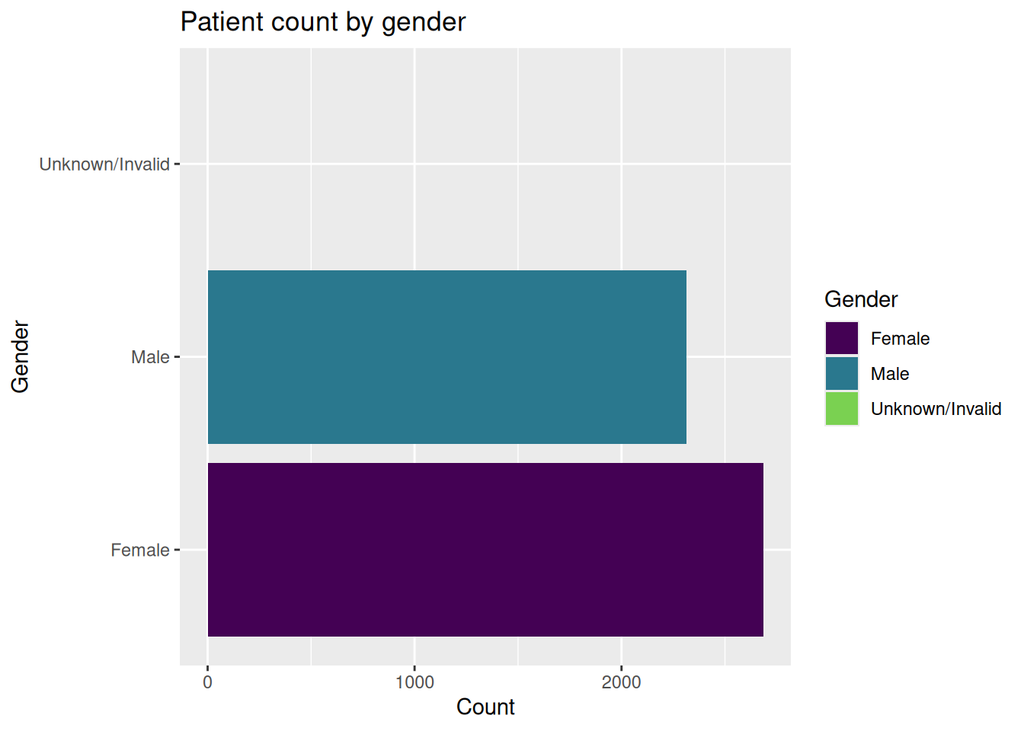

(a) My plot

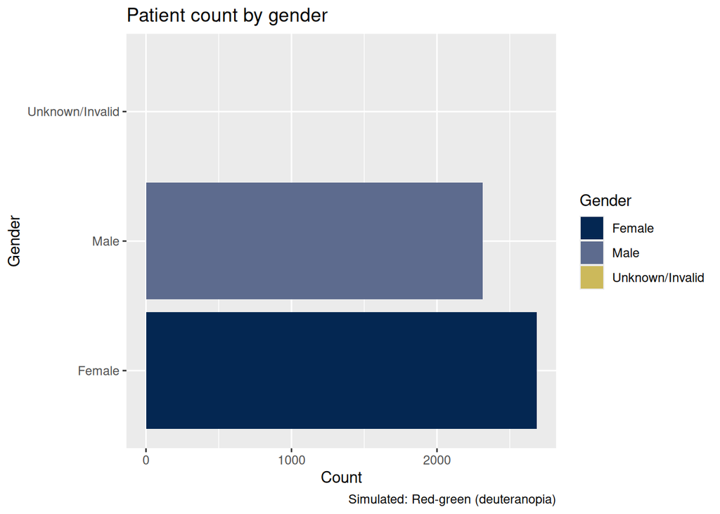

(b) Red-green (deuteranopia), simulated

Figure 5: My colors, with a second cue, and how a reader with red-green color blindness might see them.

```r
a5 <- ggplot(a_data, aes(y = group, fill = group)) +
  geom_bar() +
  scale_fill_viridis_d(end = 0.8) +
  labs(
    title = "Patient count by gender",
    x = "Count",
    y = "Gender",
    fill = "Gender"
  )

# YOUR TURN: remove the # signs below, then replace each ___ (the same
# column in both places, so its name is on the axis too).
# a5 <- ggplot(a_data, aes(y = ___, fill = ___)) +
#   geom_bar() +
#   scale_fill_viridis_d(end = 0.8) +
#   labs(title = "___", x = "Count", y = "___", fill = "___")

show_plot(a5)
# See it: your plot as a reader with red-green color blindness might see it.
show_plot(simulate_plot(a5, "Red-green (deuteranopia)"))
```

```r
color_check(a5)
```

```
3 colors. The red-green simulations come from a validated model;
the blue-yellow one is an approximation.
```

```
# A tibble: 3 × 3
  view                      smallest_difference at_least_20
  <chr>                                   <dbl> <chr>
1 Red-green (deuteranopia)                 30.5 Yes
2 Red-green (protanopia)                   41.1 Yes
3 Blue-yellow (approximate)                29.7 Yes
```

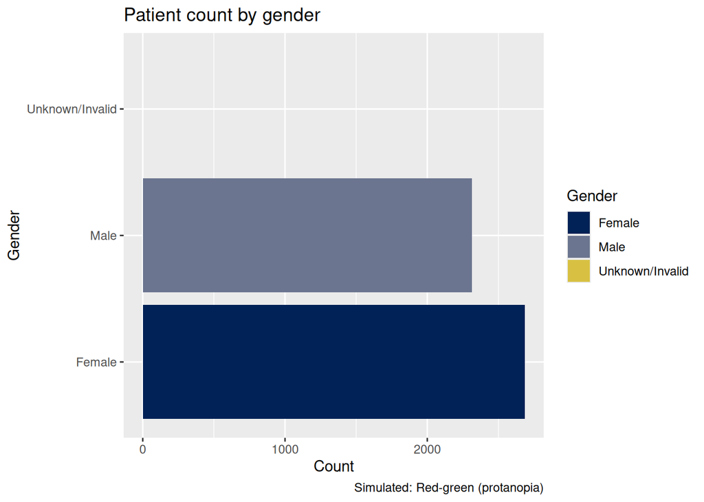

(a) Red-green (protanopia), simulated

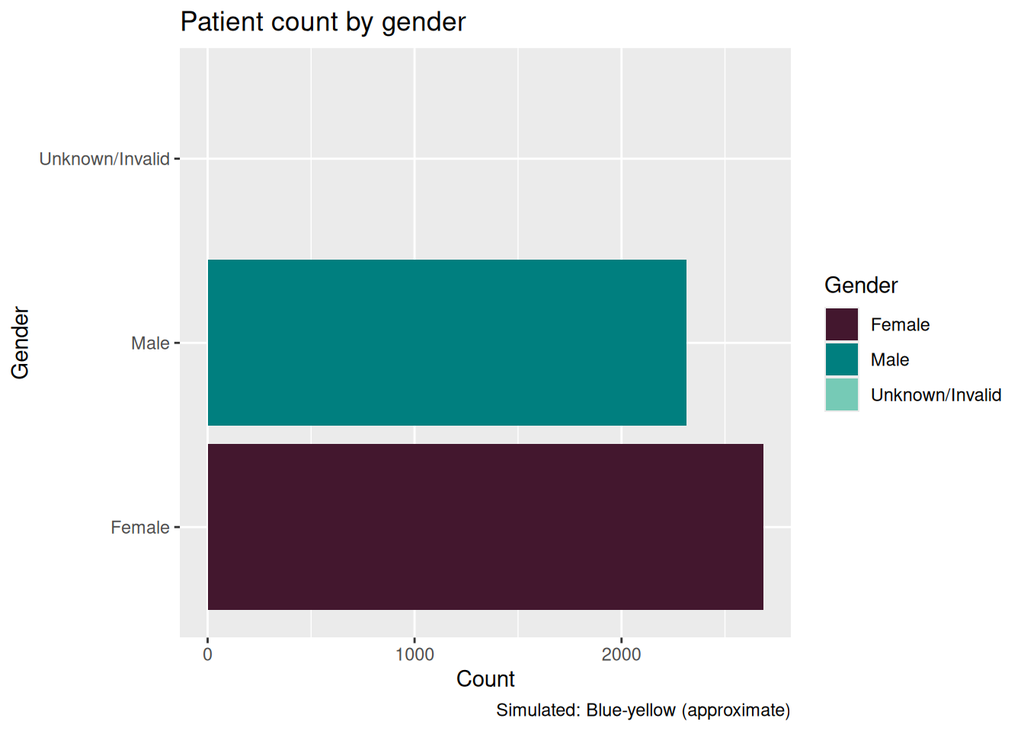

(b) Blue-yellow (approximate), simulated

Figure 6: The other two simulated views.

```r
show_plot(simulate_plot(a5, "Red-green (protanopia)"))
show_plot(simulate_plot(a5, "Blue-yellow (approximate)"))
```

## Part B · Sports

### B1 · Label it

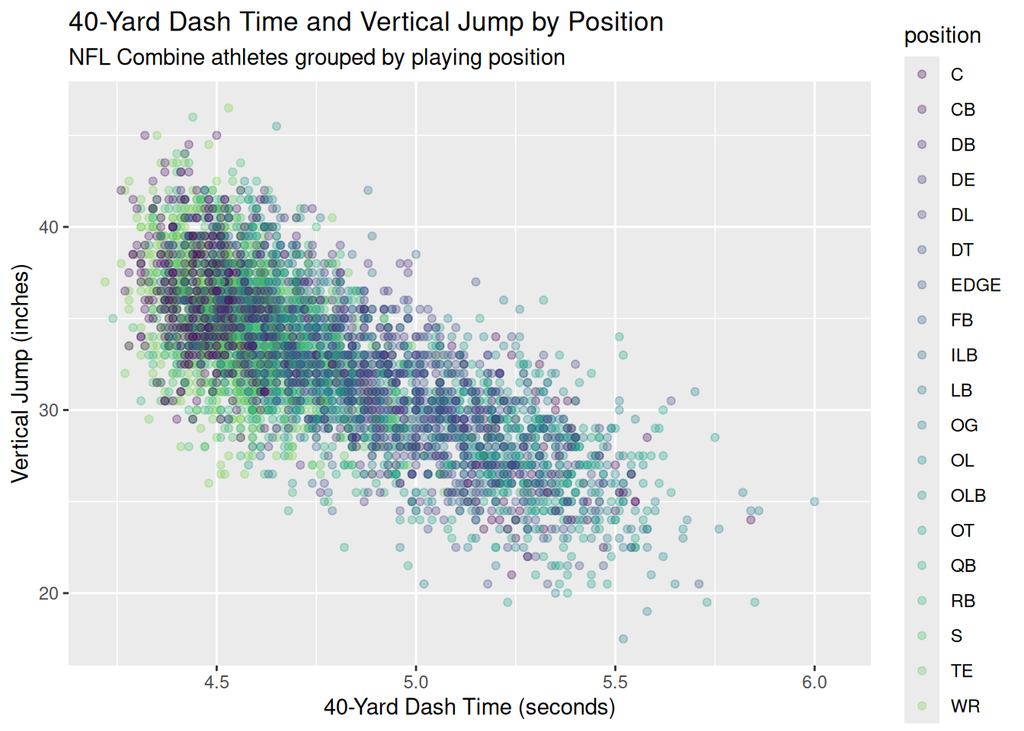

Figure 7: My Sports plot, labeled for a reader.

```r
b_data <- sports %>%
  mutate(
    group = position,
    has_outcome = FALSE,
    value = forty
  )

b1_base <- ggplot(
  sports,
  aes(x = forty, y = vertical, color = position)
) +
  geom_point(alpha = 0.3)

b1 <- b1_base +
  labs(
    title = "40-Yard Dash Time and Vertical Jump by Position",
    subtitle = "NFL Combine athletes grouped by playing position",
    x = "40-Yard Dash Time (seconds)",
    y = "Vertical Jump (inches)"
  )

show_plot(b1)
```

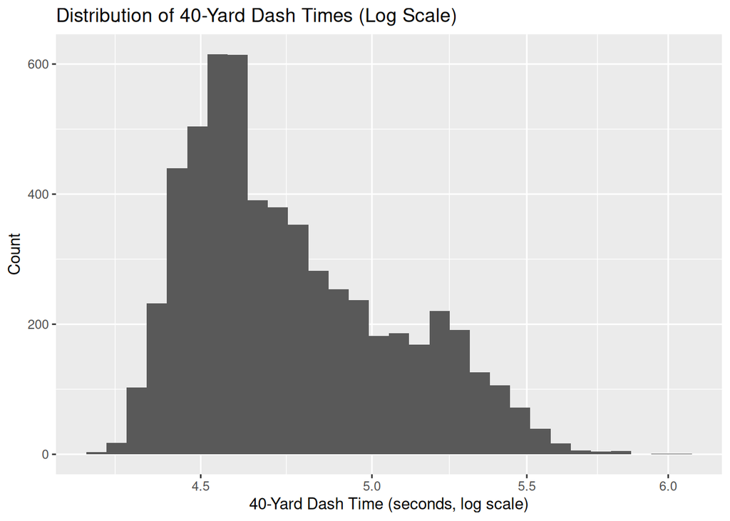

Figure 8: My scale choice.

```r
b2 <- ggplot(sports, aes(x = forty)) +
  geom_histogram(bins = 30) +
  scale_x_log10() +
  labs(
    title = "Distribution of 40-Yard Dash Times (Log Scale)",
    x = "40-Yard Dash Time (seconds, log scale)",
    y = "Count"
  )

b2_reason <- "I used a log scale because the forty-yard dash times are somewhat right-skewed, and the log transformation makes the distribution easier to see by reducing the influence of extreme values."

show_plot(b2)
```

### B3 · Facet it: fixed or free

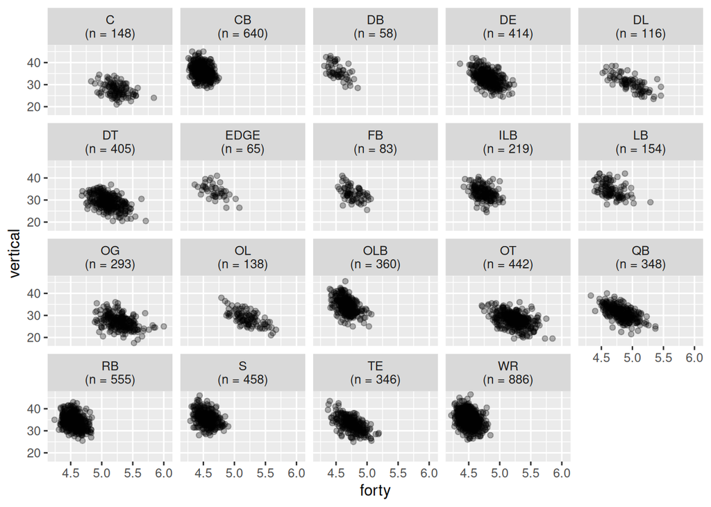

(a) Fixed

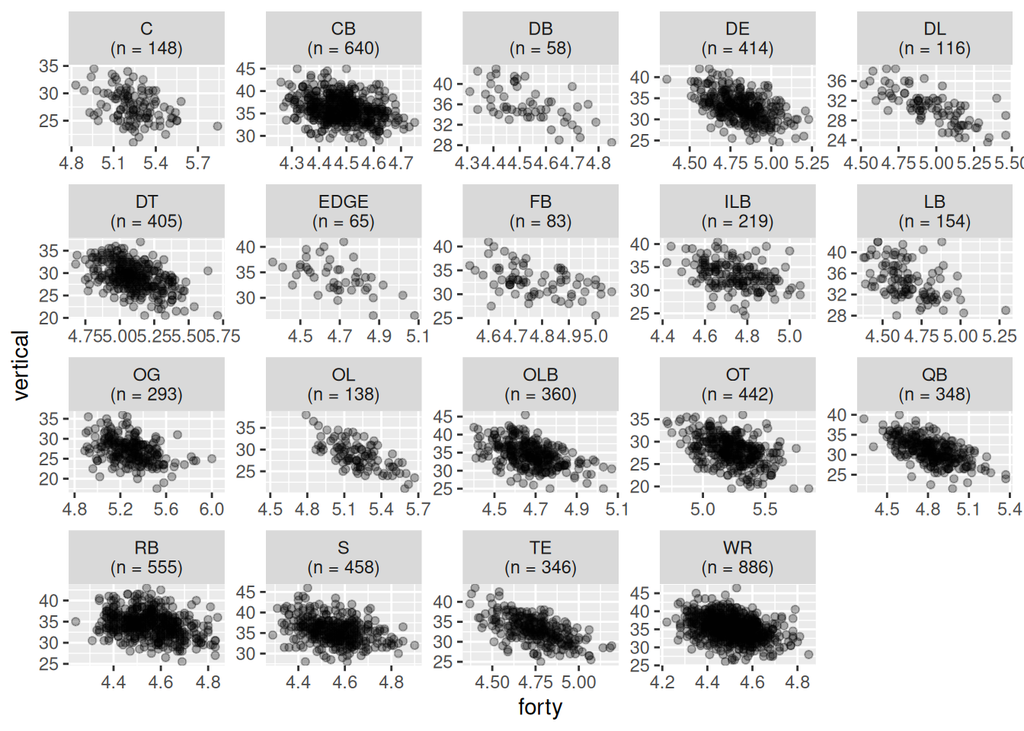

(b) Free

```r
position_counts <- sports %>%
  count(position) %>%
  mutate(label = paste0(position, "\n(n = ", n, ")"))

sports_b3 <- sports %>%
  left_join(position_counts, by = "position")

b3_fixed <- ggplot(sports_b3,
                   aes(x = forty, y = vertical)) +
  geom_point(alpha = 0.3) +
  facet_wrap(~ label)

b3_free <- ggplot(sports_b3,
                  aes(x = forty, y = vertical)) +
  geom_point(alpha = 0.3) +
  facet_wrap(~ label, scales = "free")

b3_choice <- "fixed"

b3_reason <- "I chose fixed scales because they make it easier to compare the relationship between forty-yard dash time and vertical jump across positions using the same axes."

show_plot(b3_fixed)
show_plot(b3_free)
```

WRITE (3–4 sentences): Fixed or free? What does the reader gain, and what do they lose? Which panels are small, and what is their n? Differences, not causes.

I would publish the fixed version because all panels use the same axes, making it easier to compare player positions directly. Readers gain more accurate comparisons between positions, although some position-specific patterns may be less noticeable than in the free-scale version. The panel labels include the sample size (n) for each position, and positions with smaller sample sizes should be interpreted more cautiously because they have fewer observations. The plots show differences in 40-yard dash times and vertical jump heights across positions, but they do not explain the causes of those differences.

### B4 · Compared to what?

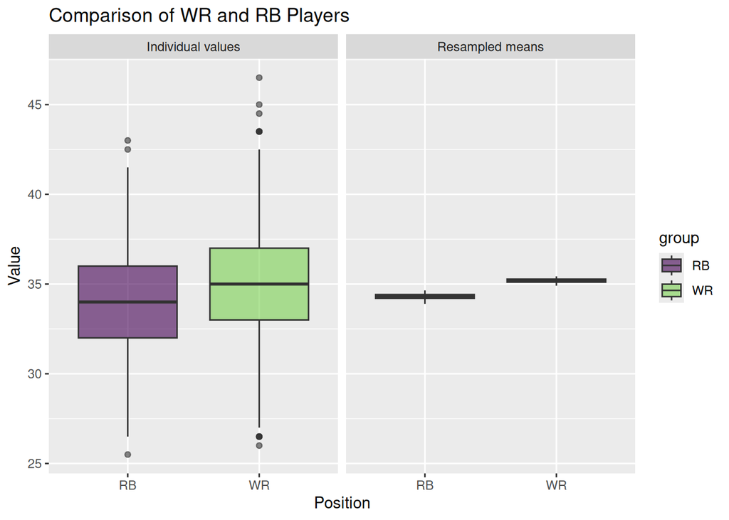

Figure 10: Two groups: individual values and resampled means, same axes.

```r
b4_clouds <- make_clouds(
  sports %>% filter(position %in% c("WR", "RB")),
  position,
  vertical
)

b4 <- ggplot(b4_clouds, aes(x = group, y = value, fill = group)) +
  geom_boxplot(alpha = 0.6) +
  facet_wrap(~ kind) +
  labs(
    title = "Comparison of WR and RB Players",
    x = "Position",
    y = "Value"
  )

show_plot(b4)
```

WRITE (2–3 sentences): Do the clouds overlap? What does that say about individuals versus the group means?

The clouds overlap, which indicates that many individual wide receivers and running backs have similar vertical jump measurements. The resampled means overlap less than the individual values, making differences between the average performance of the two groups easier to see. This suggests that while individual players may be similar, the group averages can still differ.

### B5 · Color for every reader

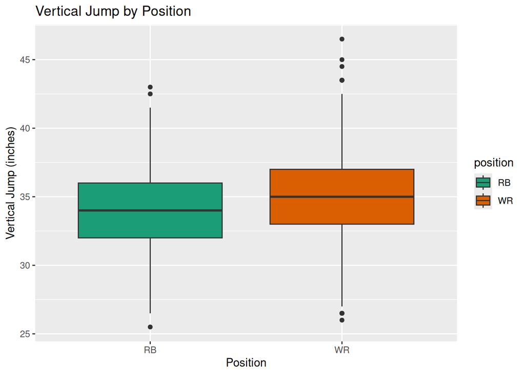

(a) My plot

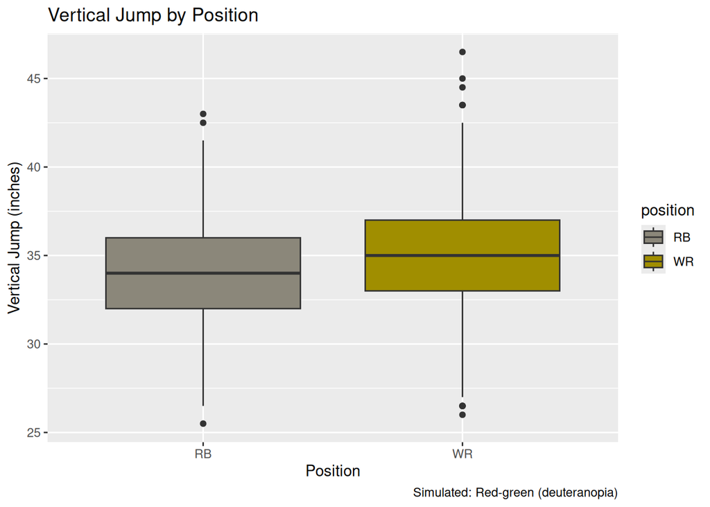

(b) Red-green (deuteranopia), simulated

Figure 11: My colors, with a second cue, and how a reader with red-green color blindness might see them.

```r
b5_data <- sports %>%
  filter(position %in% c("WR", "RB"))

b5 <- ggplot(
  b5_data,
  aes(x = position, y = vertical, fill = position)
) +
  geom_boxplot() +
  scale_fill_brewer(palette = "Dark2") +
  labs(
    title = "Vertical Jump by Position",
    x = "Position",
    y = "Vertical Jump (inches)"
  )

show_plot(b5)
show_plot(simulate_plot(b5, "Red-green (deuteranopia)"))
```

```r
color_check(b5)
```

```
2 colors. The red-green simulations come from a validated model;
the blue-yellow one is an approximation.
```

```
# A tibble: 3 × 3
  view                      smallest_difference at_least_20
  <chr>                                   <dbl> <chr>
1 Red-green (deuteranopia)                 55.7 Yes
2 Red-green (protanopia)                   39.5 Yes
3 Blue-yellow (approximate)               110.  Yes
```

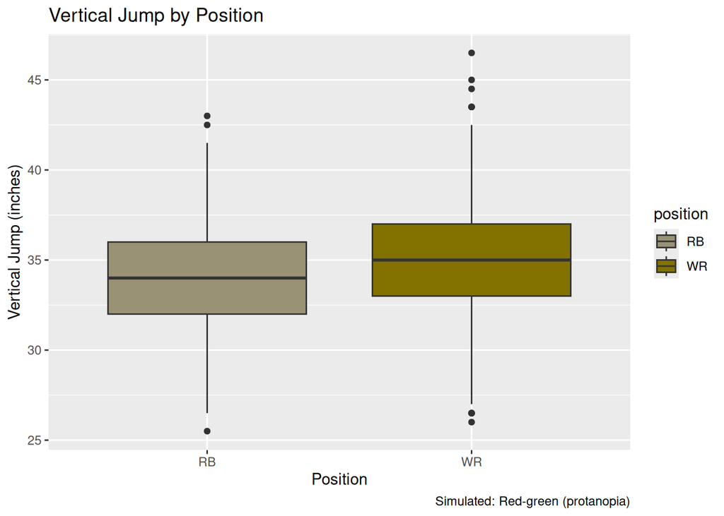

(a) Red-green (protanopia), simulated

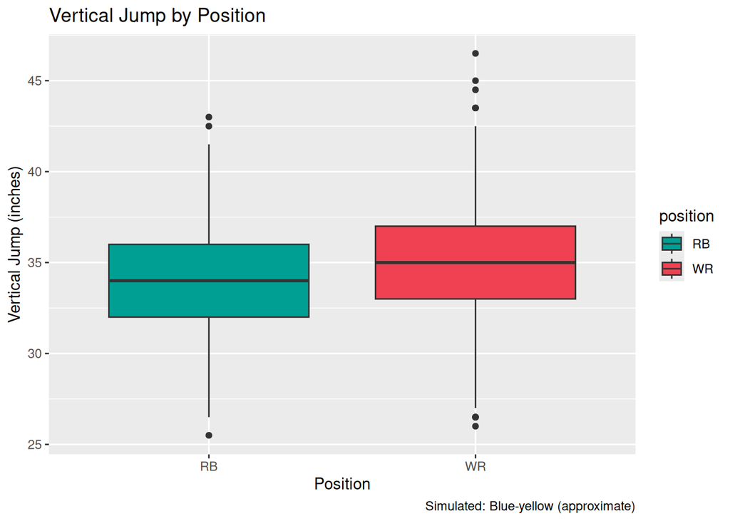

(b) Blue-yellow (approximate), simulated

Figure 12: The other two simulated views.

```r
show_plot(simulate_plot(b5, "Red-green (protanopia)"))
show_plot(simulate_plot(b5, "Blue-yellow (approximate)"))
```

WRITE (2–4 sentences): Explain your colors. Say which column you colored by and why. If your first choice failed the color check, say what you changed: fewer categories, grouping rare ones, or panels. Then look at your simulated plot: can you still tell the categories apart?

I colored the plot by position because the goal is to compare wide receivers (WR) and running backs (RB). I limited the plot to these two positions after reducing the number of categories, which makes the colors easier to distinguish and improves accessibility. The Dark2 palette provides good contrast, and position is also shown on the x-axis as a second cue. In the simulated color-blind views, the two categories are still easy to tell apart.

## One thing I tried in my slides, and why

WRITE (2–3 sentences): One idea of your own in your slides (an angle, a comparison, an order, an annotation), and how it helps a reader see the finding.

One idea I used in my slides was comparing NFL Combine performance by player position using facets and group summaries. This helps readers see how positions differ in 40-yard dash times and vertical jump heights while keeping the comparisons organized and easy to follow. Showing the average values for each position also makes the overall patterns easier to understand than looking at individual player data alone.

## Revision log

Fill this in for the final: three to five changes to your report or slides. For each: what changed, why, and which idea from Module 14 it uses.

| Change | Why | Module 14 idea |
| --- | --- | --- |
| Added clearer titles and axis labels to all fairness and sports plots. | This makes the plots easier to understand without additional explanation | Label plots for the reader. |

[output not shown]

[output not shown]

## Checks

Table 2: Every task’s check, at the time this page was rendered.

| task | status |
| --- | --- |
| A0 | see the reminder |
| A1 | PASS |
| A2 | PASS |
| A3 | PASS |
| A4 | PASS |
| A5 | PASS |
| B1 | PASS |
| B2 | PASS |
| B3 | PASS |
| B4 | PASS |
| B5 | PASS |

## References

WRITE: APA references for your Fairness dataset (Fairlearn and the original source) and your Sports dataset (its SCORE page). Fairlearn. (n.d.). Diabetes 130-US hospitals for years 1999–2008 data set [Data set]. Fairlearn. Original source: Strack, B., DeShazo, J. P., Gennings, C., Olmo, J. L., Ventura, S., Cios, K. J., & Clore, J. N. (2014). Impact of HbA1c measurement on hospital readmission rates: Analysis of 70,000 clinical database patient records. BioMed Research International, 2014, Article 781670. https://doi.org/10.1155/2014/781670

SCORE Network. (n.d.). NFL Combine data set [Data set]. SCORE course data repository.